# Predicting Heart Failure Using Clinical Records

## Phase 2 : Predictive modeling

#### Group Number: 45

**Name(s) & ID(s) of Group Members:**

- Shreyas Ainapur, s3928704
- Saisiva Devulapalli, s3931923
1. Introduction  
   1.1. Phase 1 Summary  
   1.2. Report Overview  
   1.3. Overview of Methodology
2. Predictive Modelling  
   2.1. Feature Selection (FS)  
   2.2. Model Fitting & Tuning

   > 2.2.1 KNN  
   > 2.2.2 Naive Bayes  
   > 2.2.3 Decision Tree  
   > 2.2.4 XGBoost  
   > 2.2.5 Neural Network Model Fitting & Tuning

   2.3. Model Comparison
3. Critique & Limitations
4. Summary & Conclusions  
   4.1. Project Summary  
   4.2. Summary of Findings  
   4.3. Conclusions
5. References

## 1. Introduction

### 1.1. Phase 1 Summary :

Using clinical record data, predicting the probability of heart failure in a patient has numerous real-time applications. The data provided details of the health problems of heart disease patients and includes features such as age, gender, smoking habits, serum sodium level, ejection fraction, creatinine phosphokinase levels, and follow-up time length. An application can be made which provides analysis and insights using the data & can be used by healthcare providers in hospitals or by individuals for early detection, thereby reducing the risk of heart failure-related deaths.

During the first phase of our project, we took performed several important data prepartion steps. First, we clearly defined the dataset's source and provided a summary and the background information related to the data collection. We then briefly described each attribute, including its data type and unit of measurement, and identified the target feature, which is predicting the DEATH_EVENT using the dataset attributes.

Next, we conducted data cleaning and preprocessing tasks. Although we considered dropping some of the dataset's irrelevant features, we ultimately retained all 13 columns because they were essential as they are related to cardiovascular diseases and these are clinical observations . We also performed exploratory data analysis, checking for null values and replacing binary values with appropriate nominal categorical objects for better readability.

To ensure data accuracy, we ran boxplots to identify outliers and used the z-score function to remove them. We also checked for any anomalies in the data and rounded the Age column to the nearest whole number for better analysis and readability. Finally, we converted the attribute data types, resulting in a thoroughly cleaned and processed dataset.

During the next task, we created various visual representations to analyze our collected data. These visualizations included univariate, bivariate, and multivariate graphs. We used histograms to show the distribution of age and ejection percentage and violin plots to represent the distribution of serum sodium. Bar plots were used to compare follow-up time with the death event and smoking habits with age. Line graphs were used to compare age and ejection percentage. Additionally, we used box plots to show how serum sodium varied according to sex and death event, and scatter plots to display the correlation between the follow-up duration, creatinine phosphokinase levels, and the death event.

### 1.2. Report Overview :

Our goal for Phase 2 of this project is to develop a model that can predict which patients are at a higher risk of death due to heart failure. To achieve this, we will use pre-processed and cleaned data from Phase 1. We will identify the key features, explore different machine learning algorithms, evaluate their performance, and ensure fairness while assessing limitations.

### 1.3. Overview of Methodology :

To begin the analysis, we imported the necessary libraries, such as pandas, numpy, and sklearn. We then loaded the data from phase 1 pandas DataFrame using the read_csv() function. We then selected the relevant features for the analysis by identifying the columns that had a significant impact on the target variable or were informative. The dataset was then split into training and testing sets using the train_test_split() function from sklearn, allowing for the assessment of the model's performance on unseen data.

## 2. Predictive Modelling

```python
#importing all the required packages
from io import StringIO
import seaborn as sns
import matplotlib.pyplot as plt
from matplotlib import pyplot
import numpy as np
import pandas as pd
pd.set_option('display.max_columns', None)

from sklearn import preprocessing
from sklearn.preprocessing import LabelEncoder
from sklearn.ensemble import RandomForestClassifier
from sklearn.model_selection import train_test_split
from sklearn.model_selection import StratifiedKFold, GridSearchCV
from sklearn.metrics import mean_squared_error,mean_absolute_error
from sklearn.metrics import confusion_matrix
from sklearn.metrics import r2_score

from keras.models import Sequential
from keras.layers import Dense, Dropout
from sklearn.metrics import accuracy_score, roc_auc_score
from tensorflow.keras.optimizers import SGD
from keras.layers import ELU, PReLU, LeakyReLU

from sklearn.model_selection import cross_val_score
from sklearn.model_selection import KFold

#filter warnings in output cells
import warnings
warnings.filterwarnings('ignore')
```

We are using the pre-processed, cleaned data from the Phase 1.

```python
#reading the data from local directory
heart_data = pd.read_csv("Phase2_Group45.csv")
heart_data.head(5)
```

|  | age | anaemia | creatinine_phosphokinase | diabetes | ejection_fraction | high_blood_pressure | platelets | serum_creatinine | serum_sodium | sex | smoking | time | DEATH_EVENT |
| --- | --- | --- | --- | --- | --- | --- | --- | --- | --- | --- | --- | --- | --- |
| 0 | 75 | 0 | 582 | 0 | 20 | 1 | 265000.0 | 1.9 | 130 | male | non-smoker | 4 | Deceased |
| 1 | 65 | 0 | 146 | 0 | 20 | 0 | 162000.0 | 1.3 | 129 | male | smoker | 7 | Deceased |
| 2 | 50 | 1 | 111 | 0 | 20 | 0 | 210000.0 | 1.9 | 137 | male | non-smoker | 7 | Deceased |
| 3 | 90 | 1 | 47 | 0 | 40 | 1 | 204000.0 | 2.1 | 132 | male | smoker | 8 | Deceased |
| 4 | 75 | 1 | 246 | 0 | 15 | 0 | 127000.0 | 1.2 | 137 | male | non-smoker | 10 | Deceased |

```python
# Analysing the correlation between different features in the dataset
hear_data_corr = heart_data.corr()
print(hear_data_corr.corr())
```

```
                               age   anaemia  creatinine_phosphokinase  \
age                       1.000000  0.089022                 -0.344244
anaemia                   0.089022  1.000000                 -0.366345
creatinine_phosphokinase -0.344244 -0.366345                  1.000000
diabetes                 -0.269708 -0.117763                 -0.028780
ejection_fraction         0.072174  0.025799                 -0.244875
high_blood_pressure       0.109041 -0.005211                 -0.195972
platelets                -0.150420 -0.114277                 -0.187314
serum_creatinine          0.376382 -0.153981                 -0.226760
serum_sodium             -0.206786  0.104508                  0.055895
time                     -0.545819 -0.314521                  0.308698

                          diabetes  ejection_fraction  high_blood_pressure  \
age                      -0.269708           0.072174             0.109041
anaemia                  -0.117763           0.025799            -0.005211
creatinine_phosphokinase -0.028780          -0.244875            -0.195972
diabetes                  1.000000          -0.157661            -0.086432
ejection_fraction        -0.157661           1.000000             0.008897
high_blood_pressure      -0.086432           0.008897             1.000000
platelets                 0.026140           0.058125             0.040012
serum_creatinine         -0.112524          -0.370711            -0.141437
serum_sodium             -0.228408           0.267062            -0.067512
time                      0.030126          -0.023681            -0.459973

                          platelets  serum_creatinine  serum_sodium      time
age                       -0.150420          0.376382     -0.206786 -0.545819
anaemia                   -0.114277         -0.153981      0.104508 -0.314521
creatinine_phosphokinase  -0.187314         -0.226760      0.055895  0.308698
diabetes                   0.026140         -0.112524     -0.228408  0.030126
ejection_fraction          0.058125         -0.370711      0.267062 -0.023681
high_blood_pressure        0.040012         -0.141437     -0.067512 -0.459973
platelets                  1.000000         -0.097797     -0.083860 -0.080639
serum_creatinine          -0.097797          1.000000     -0.537079 -0.319582
serum_sodium              -0.083860         -0.537079      1.000000  0.112369
time                      -0.080639         -0.319582      0.112369  1.000000
```

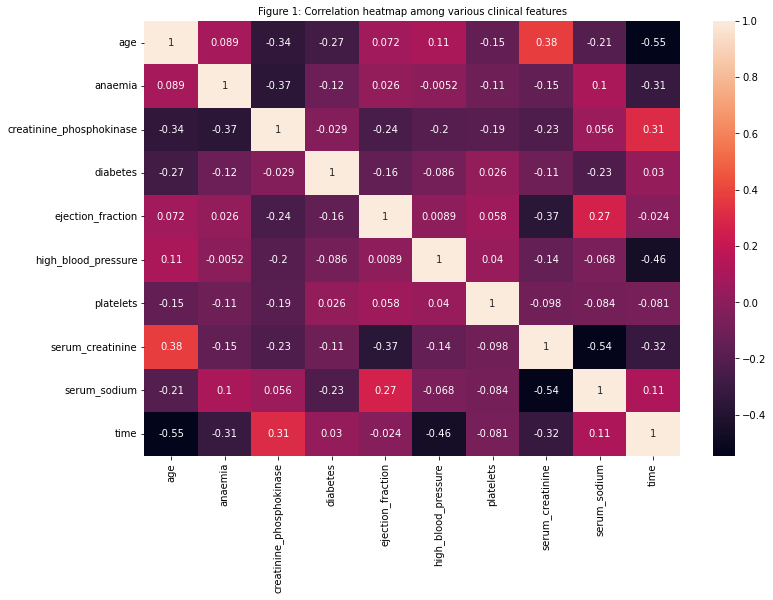

```python
# Correlatiojn Heatmap
fig, ax = plt.subplots()
fig.set_size_inches(12, 8)

fig = sns.heatmap(hear_data_corr.corr(), annot=True)
plt.title('Figure 1: Correlation heatmap among various clinical features', fontsize = 10)
plt.show()
```

#### One Hot Encoding:

Since the features "sex", "smoking", and "DEATH_EVENT" have binary categorical variables that is the unique values present in these 3 categorical columns are only 2 we convert these columns into single binary column instead of performing one hot encoding.

```python
print(heart_data['sex'].unique())
print(heart_data['smoking'].unique())
print(heart_data['DEATH_EVENT'].unique())
```

```
['male' 'female']
['non-smoker' 'smoker']
['Deceased' 'Not-Deceased']
```

```python
# Performing label encoding
label_encoder = LabelEncoder()
heart_data['sex'] = label_encoder.fit_transform(heart_data['sex'])
heart_data['smoking'] = label_encoder.fit_transform(heart_data['smoking'])
heart_data['DEATH_EVENT'] = label_encoder.fit_transform(heart_data['DEATH_EVENT'])

heart_data.head()
```

|  | age | anaemia | creatinine_phosphokinase | diabetes | ejection_fraction | high_blood_pressure | platelets | serum_creatinine | serum_sodium | sex | smoking | time | DEATH_EVENT |
| --- | --- | --- | --- | --- | --- | --- | --- | --- | --- | --- | --- | --- | --- |
| 0 | 75 | 0 | 582 | 0 | 20 | 1 | 265000.0 | 1.9 | 130 | 1 | 0 | 4 | 0 |
| 1 | 65 | 0 | 146 | 0 | 20 | 0 | 162000.0 | 1.3 | 129 | 1 | 1 | 7 | 0 |
| 2 | 50 | 1 | 111 | 0 | 20 | 0 | 210000.0 | 1.9 | 137 | 1 | 0 | 7 | 0 |
| 3 | 90 | 1 | 47 | 0 | 40 | 1 | 204000.0 | 2.1 | 132 | 1 | 1 | 8 | 0 |
| 4 | 75 | 1 | 246 | 0 | 15 | 0 | 127000.0 | 1.2 | 137 | 1 | 0 | 10 | 0 |

#### Separating the target variable from dataframe:

```python
data = heart_data.drop(columns='DEATH_EVENT')
target = heart_data['DEATH_EVENT']
```

### 2.1. Feature Selection (FS) :

Comparing the importance of each features using Random Forest Importance (RFI). This is for a fast ranking of all the characteristics to gain insights int the current scenario. During the hyperparameter tuning phase, we will include RFI as part of the pipeline and we will search over 6, 8, and the full set of 12 features to determine which number of features works best with each classifier.

```python
num_features = 12
model_rfi = RandomForestClassifier(n_estimators=100)
model_rfi.fit(data, target)
fs_indices_rfi = np.argsort(model_rfi.feature_importances_)[::-1][0:num_features]

best_features_rfi = heart_data.columns[fs_indices_rfi].values
print(best_features_rfi)
```

```
['time' 'serum_creatinine' 'ejection_fraction' 'creatinine_phosphokinase'
 'age' 'serum_sodium' 'platelets' 'smoking' 'diabetes' 'sex' 'anaemia'
 'high_blood_pressure']
```

```python
feature_importances_rfi = model_rfi.feature_importances_[fs_indices_rfi]
print(feature_importances_rfi)
```

```
[0.33013321 0.14234776 0.12181713 0.0904586  0.08823049 0.08587641
 0.0816026  0.01505432 0.01358019 0.01081561 0.01007891 0.01000477]
```

#### Visulaizing the importance of the features:

```python
import matplotlib.pyplot as plt
%matplotlib inline
%config InlineBackend.figure_format = 'retina'
plt.style.use("ggplot")

def plot_imp(best_features, scores, method_name):
    plt.barh(best_features, scores)
    plt.title(method_name + ' Feature Importances')
    plt.xlabel("Importance")
    plt.ylabel("Features")
    plt.show()
```

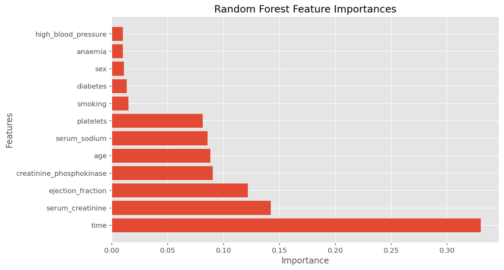

```python
plt.figure(figsize=(10, 6))
plot_imp(best_features_rfi, feature_importances_rfi, 'Random Forest')
```

In the above plot, length of the bar represnts the importance of the feature. Longer the length higher the importance. Here we see that the most important feature to determine if the patient is deceased is "time" followed by "serum_creatinine", and "ejection_fraction". Here time implies the follow up period of patient in days.

#### Splitting data into Train-Test data :

```python
Data_sample = pd.DataFrame(data).values
target_sample = pd.DataFrame(target).values

print(Data_sample.shape)
print(target_sample.shape)

## Using the train_test_split function data is divided into training and testing sets 80:20 ratio respectively
Data_sample_train, Data_sample_test, \
target_sample_train, target_sample_test = train_test_split(Data_sample, target_sample,
                                                    test_size = 0.2, random_state=999,
                                                    stratify = target_sample)

print(Data_sample_train.shape)
print(Data_sample_test.shape)
```

```
(279, 12)
(279, 1)
(223, 12)
(56, 12)
```

### 2.2. Model Fitting & Tuning :

Using the 80:20 ratio, the data set is divided into training and testing data sets repectively. Which imples, 223 observations will be used for training and remaining 56 observartions will be used for testing. Each model's hyperparameters are tuned using the 5-fold stratified cross-validation assessment approach.

```python
cv_method = StratifiedKFold(n_splits=5, shuffle=True, random_state=999)
```

### 2.2.1 K-Nearest Neighbors :

Using Pipeline, we stack feature selection and grid search for KNN hyperparameter tuning via cross-validation.  
The KNN hyperparameters are as follows:

- number of neighbors (n_neighbors) and
- the distance metric p

For feature selection, we use the powerful Random Forest Importance (RFI) method with 100 estimators.To make RFI feature selection as part of the pipeline we define the custom RFIFeatureSelector() class below to pass in RFI as a "step" to the pipeline.

```python
from sklearn.base import BaseEstimator, TransformerMixin

# custom function for RFI feature selection inside a pipeline
# here we use n_estimators=100
class RFIFeatureSelector(BaseEstimator, TransformerMixin):

    # class constructor
    # make sure class attributes end with a "_"
    # per scikit-learn convention to avoid errors
    def __init__(self, n_features_=8):
        self.n_features_ = n_features_
        self.fs_indices_ = None

    # override the fit function
    def fit(self, X, y):
        from sklearn.ensemble import RandomForestClassifier
        from numpy import argsort
        model_rfi = RandomForestClassifier(n_estimators=100)
        model_rfi.fit(X, y)
        self.fs_indices_ = argsort(model_rfi.feature_importances_)[::-1][0:self.n_features_]
        return self

    # override the transform function
    def transform(self, X, y=None):
        return X[:, self.fs_indices_]
```

```python
from sklearn.pipeline import Pipeline
from sklearn.neighbors import KNeighborsClassifier

pipe_KNN = Pipeline(steps=[('rfi_fs', RFIFeatureSelector()),
                           ('knn', KNeighborsClassifier())])

params_pipe_KNN = {'rfi_fs__n_features_': [6, 8, heart_data.shape[1]],
                   'knn__n_neighbors': [1, 3, 6, 9, 12],
                   'knn__p': [1, 2]}

gs_pipe_KNN = GridSearchCV(estimator=pipe_KNN,
                           param_grid=params_pipe_KNN,
                           cv=cv_method,
                           refit=True,
                           n_jobs=-2,
                           scoring='roc_auc',
                           verbose=1)
```

```python
gs_pipe_KNN.fit(Data_sample_train, target_sample_train);
```

```
Fitting 5 folds for each of 30 candidates, totalling 150 fits
```

```python
gs_pipe_KNN.best_params_
```

```
{'knn__n_neighbors': 12, 'knn__p': 1, 'rfi_fs__n_features_': 6}
```

```python
gs_pipe_KNN.best_score_
```

```
0.764604750088621
```

Even though these are the best values, below we can see if there is any significant difference with different hyperparatmeter values. For this, we will format the grid search outputs as a Pandas data frame.

```python
# custom function to format the search results as a Pandas data frame
def get_search_results(gs):

    def model_result(scores, params):
        scores = {'mean_score': np.mean(scores),
             'std_score': np.std(scores),
             'min_score': np.min(scores),
             'max_score': np.max(scores)}
        return pd.Series({**params,**scores})

    models = []
    scores = []

    for i in range(gs.n_splits_):
        key = f"split{i}_test_score"
        r = gs.cv_results_[key]
        scores.append(r.reshape(-1,1))

    all_scores = np.hstack(scores)
    for p, s in zip(gs.cv_results_['params'], all_scores):
        models.append((model_result(s, p)))

    pipe_results = pd.concat(models, axis=1).T.sort_values(['mean_score'], ascending=False)

    columns_first = ['mean_score', 'std_score', 'max_score', 'min_score']
    columns = columns_first + [c for c in pipe_results.columns if c not in columns_first]

    return pipe_results[columns]
```

```python
results_KNN = get_search_results(gs_pipe_KNN)
results_KNN.head()
```

|  | mean_score | std_score | max_score | min_score | knn__n_neighbors | knn__p | rfi_fs__n_features_ |
| --- | --- | --- | --- | --- | --- | --- | --- |
| 24 | 0.764605 | 0.070766 | 0.843672 | 0.632488 | 12.0 | 1.0 | 6.0 |
| 27 | 0.691049 | 0.124862 | 0.837469 | 0.481567 | 12.0 | 2.0 | 6.0 |
| 18 | 0.690411 | 0.129094 | 0.857320 | 0.536866 | 9.0 | 1.0 | 6.0 |
| 21 | 0.673041 | 0.149803 | 0.856079 | 0.449309 | 9.0 | 2.0 | 6.0 |
| 0 | 0.655069 | 0.072277 | 0.736973 | 0.533410 | 1.0 | 1.0 | 6.0 |

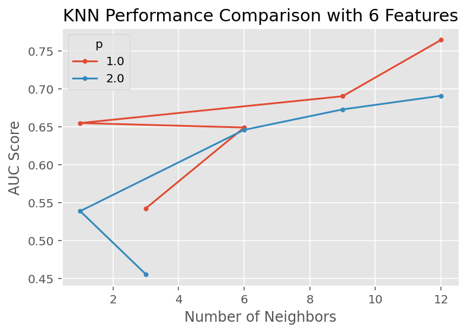

```python
results_KNN_6_features = results_KNN[results_KNN['rfi_fs__n_features_'] == 6.0]

for i in results_KNN_6_features['knn__p'].unique():
    temp = results_KNN_6_features[results_KNN_6_features['knn__p'] == i]
    plt.plot(temp['knn__n_neighbors'], temp['mean_score'], marker = '.', label = i)

plt.legend(title = "p")
plt.xlabel('Number of Neighbors')
plt.ylabel("AUC Score")
plt.title("KNN Performance Comparison with 6 Features")
plt.show()
```

### 2.2.2 Naive Bayes(NB) :

Similar to KNN, we use pipeline methodology for NB.  
The hyperparameter for NB is :  
var_smoothing

We optimize var_smoothing. By default, the var_smoothing parameter's value is 10−9. We conduct the grid search in the logspace (over the powers of 10) sourced from NumPy. We start with 10 and end with 10−3 with 200 different values, but we perform a random search over only 20 different values. Since NB requires each descriptive feature to follow a Gaussian distribution, we first perform a power transformation on the input data before model fitting.

```python
from sklearn.preprocessing import PowerTransformer
X_train_transformed = PowerTransformer().fit_transform(Data_sample_train)
```

```python
from sklearn.naive_bayes import GaussianNB
from sklearn.model_selection import RandomizedSearchCV

pipe_NB = Pipeline([('rfi_fs', RFIFeatureSelector()),
                     ('nb', GaussianNB())])

params_pipe_NB = {'rfi_fs__n_features_': [6, 8, heart_data.shape[1]],
                  'nb__var_smoothing': np.logspace(1,-3, num=200)}

n_iter_search = 20
gs_pipe_NB = RandomizedSearchCV(estimator=pipe_NB,
                          param_distributions=params_pipe_NB,
                          cv=cv_method,
                          refit=True,
                          n_jobs=-2,
                          scoring='roc_auc',
                          n_iter=n_iter_search,
                          verbose=1)

gs_pipe_NB.fit(X_train_transformed, target_sample_train);
```

```
Fitting 5 folds for each of 20 candidates, totalling 100 fits
```

```python
gs_pipe_NB.best_params_
```

```
{'rfi_fs__n_features_': 6, 'nb__var_smoothing': 0.08504489341802678}
```

```python
gs_pipe_NB.best_score_
```

```
0.9078341013824884
```

Even though these are the best values, below we can see if there is any significant difference with different hyperparatmeter values. For this, we will format the grid search outputs as a Pandas data frame.

```python
results_NB = get_search_results(gs_pipe_NB)
results_NB.head()
```

|  | mean_score | std_score | max_score | min_score | rfi_fs__n_features_ | nb__var_smoothing |
| --- | --- | --- | --- | --- | --- | --- |
| 15 | 0.907834 | 0.032968 | 0.951613 | 0.866359 | 6.0 | 0.085045 |
| 5 | 0.907799 | 0.032736 | 0.953917 | 0.873272 | 6.0 | 0.310787 |
| 18 | 0.907302 | 0.034286 | 0.956221 | 0.866359 | 6.0 | 0.357079 |
| 6 | 0.905814 | 0.033366 | 0.951613 | 0.870968 | 6.0 | 0.002097 |
| 2 | 0.903509 | 0.025636 | 0.935484 | 0.875576 | 8.0 | 0.064424 |

When the number of features is taken into consideration, we see that there is not much of a difference between the hyperparameter combinations.  
Below is the visualization of the results of the grid search corresponding to 6 selected features.

[figure not shown]

```python
results_NB_6_features = results_NB[results_NB['rfi_fs__n_features_'] == 6.0].sort_values('nb__var_smoothing')

plt.plot(results_NB_6_features['nb__var_smoothing'], results_NB_6_features['mean_score'], marker = '.', label = i)
plt.xlabel('Var. Smoothing')
plt.ylabel("AUC Score")
plt.title("NB Performance Comparison with 8 Features")
plt.show()
```

### 2.2.3 Decision Tree (DT) :

We use similar pipeline methodology for DT.  
The hyperparameter for DT is :

- max_depth
- min_samples_split

We build a DT using gini index to maximize information gain. We aim to determine the optimal combinations of maximum depth (max_depth) and minimum sample split (min_samples_split).

```python
from sklearn.tree import DecisionTreeClassifier

pipe_DT = Pipeline([('rfi_fs', RFIFeatureSelector()),
                    ('dt', DecisionTreeClassifier(criterion='gini', random_state=111))])

params_pipe_DT = {'rfi_fs__n_features_': [6, 8, heart_data.shape[1]],
                  'dt__max_depth': [3, 4, 5],
                  'dt__min_samples_split': [2, 5]}

gs_pipe_DT = GridSearchCV(estimator=pipe_DT,
                          param_grid=params_pipe_DT,
                          cv=cv_method,
                          refit=True,
                          n_jobs=-2,
                          scoring='roc_auc',
                          verbose=1)

gs_pipe_DT.fit(Data_sample_train, target_sample_train);
```

```
Fitting 5 folds for each of 18 candidates, totalling 90 fits
```

```python
gs_pipe_DT.best_params_
```

```
{'dt__max_depth': 3, 'dt__min_samples_split': 2, 'rfi_fs__n_features_': 6}
```

```python
gs_pipe_DT.best_score_
```

```
0.8640198511166254
```

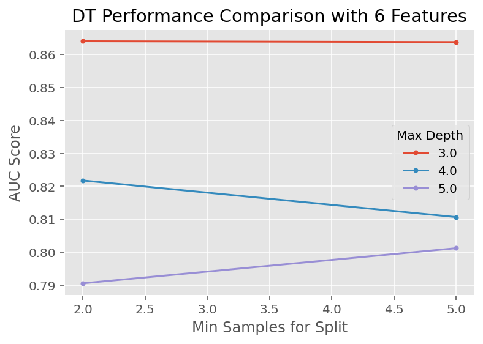

```python
results_DT = get_search_results(gs_pipe_DT)
results_DT_6_features = results_DT[results_DT['rfi_fs__n_features_'] == 6.0]


for i in results_DT_6_features['dt__max_depth'].unique():
    temp = results_DT_6_features[results_DT_6_features['dt__max_depth'] == i]
    plt.plot(temp['dt__min_samples_split'], temp['mean_score'], marker = '.', label = i)

plt.legend(title = "Max Depth")
plt.xlabel('Min Samples for Split')
plt.ylabel("AUC Score")
plt.title("DT Performance Comparison with 6 Features")
plt.show()
```

#### Further Tuning (DT)

The maximum depth hyperparameter's ideal value is found at the very edge of its search space, as can be seen. To ensure that we are not overlooking even superior values, we must therefore go above and beyond what we have already attempted. In other words, we need to observe a "elbow shape" to know where the progress ends. As a result, we attempt a new search as shown below.

```python
params_pipe_DT2 = {'rfi_fs__n_features_': [6],
                  'dt__max_depth': [5, 10, 15],
                  'dt__min_samples_split': [5, 25, 50, 100, 125, 150]}

gs_pipe_DT2 = GridSearchCV(estimator=pipe_DT,
                          param_grid=params_pipe_DT2,
                          cv=cv_method,
                          refit=True,
                          n_jobs=-2,
                          scoring='roc_auc',
                          verbose=1)

gs_pipe_DT2.fit(Data_sample_train, target_sample_train);
```

```
Fitting 5 folds for each of 18 candidates, totalling 90 fits
```

```python
gs_pipe_DT2.best_params_
```

```
{'dt__max_depth': 15, 'dt__min_samples_split': 100, 'rfi_fs__n_features_': 6}
```

```python
gs_pipe_DT2.best_score_
```

```
0.9051754696915989
```

```python
results_DT = get_search_results(gs_pipe_DT2)
results_DT.head()
```

|  | mean_score | std_score | max_score | min_score | dt__max_depth | dt__min_samples_split | rfi_fs__n_features_ |
| --- | --- | --- | --- | --- | --- | --- | --- |
| 15 | 0.905175 | 0.034591 | 0.936725 | 0.843318 | 15.0 | 100.0 | 6.0 |
| 3 | 0.904786 | 0.036855 | 0.936725 | 0.836406 | 5.0 | 100.0 | 6.0 |
| 9 | 0.904431 | 0.034877 | 0.936725 | 0.843318 | 10.0 | 100.0 | 6.0 |
| 14 | 0.904165 | 0.025611 | 0.934243 | 0.861751 | 15.0 | 50.0 | 6.0 |
| 2 | 0.901790 | 0.034888 | 0.936725 | 0.836406 | 5.0 | 50.0 | 6.0 |

Even with different hyperparameter combinations, the performance difference is not very significant.  
Below is the visulization of the search results for 6 selected features.

[figure not shown]

```python
results_DT_6_features = results_DT[results_DT['rfi_fs__n_features_'] == 6.0].sort_values('dt__min_samples_split')


for i in results_DT_6_features['dt__max_depth'].unique():
    temp = results_DT_6_features[results_DT_6_features['dt__max_depth'] == i]
    plt.plot(temp['dt__min_samples_split'], temp['mean_score'], marker = '.', label = i)

plt.legend(title = "Max Depth")
plt.xlabel('Min Samples for Split')
plt.ylabel("AUC Score")
plt.title("DT Performance Comparison with 10 Features - Extended")
plt.show()
```

### 2.2.4 XGBoost

We use similar pipeline methodology for XG.  
The hyperparameter for XG is :

- max_depth
- learning_rate

We aim to determine the optimal combinations of maximum depth (max_depth) and learning rate (learning_rate).

```python
from sklearn.ensemble import GradientBoostingClassifier
pipe_XG = Pipeline([('rfi_fs', RFIFeatureSelector()),
                    ('xg', GradientBoostingClassifier())])

params_pipe_XG = {'rfi_fs__n_features_': [6, 8, heart_data.shape[1]],
                  'xg__max_depth': [3, 6, 10],
                  'xg__learning_rate': [0.05, 0.1]}

gs_pipe_XG = GridSearchCV(estimator=pipe_XG,
                          param_grid=params_pipe_XG,
                          cv=cv_method,
                          refit=True,
                          n_jobs=-2,
                          scoring='roc_auc',
                          verbose=1)

gs_pipe_XG.fit(Data_sample_train, target_sample_train);
```

```
Fitting 5 folds for each of 18 candidates, totalling 90 fits
```

```python
gs_pipe_XG.best_score_
```

```
0.8951258419000355
```

```python
gs_pipe_XG.best_params_
```

```
{'rfi_fs__n_features_': 6, 'xg__learning_rate': 0.05, 'xg__max_depth': 3}
```

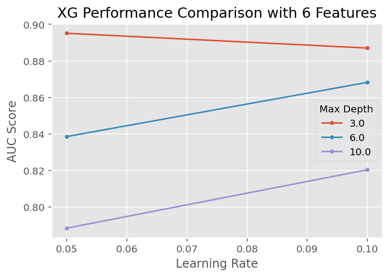

```python
results_XG = get_search_results(gs_pipe_XG)
results_XG_6_features = results_XG[results_XG['rfi_fs__n_features_'] == 6.0]


for i in results_XG_6_features['xg__max_depth'].unique():
    temp = results_XG_6_features[results_XG_6_features['xg__max_depth'] == i]
    plt.plot(temp['xg__learning_rate'], temp['mean_score'], marker = '.', label = i)

plt.legend(title = "Max Depth")
plt.xlabel('Learning Rate')
plt.ylabel("AUC Score")
plt.title("XG Performance Comparison with 6 Features")
plt.show()
```

#### Further Tuning (XGBoost) :

To ensure that we are not overlooking even superior values, we must therefore go above and beyond what we have already attempted that is we need to observe a "elbow shape" to know where the progress ends. As a result, we attempt a new search as shown below.

```python
params_pipe_XG2 = {'rfi_fs__n_features_': [6],
                  'xg__max_depth': [3, 6, 10],
                  'xg__learning_rate': [0.01, 0.05, 0.1, 0.2]}

gs_pipe_XG2 = GridSearchCV(estimator=pipe_XG,
                          param_grid=params_pipe_XG2,
                          cv=cv_method,
                          refit=True,
                          n_jobs=-2,
                          scoring='roc_auc',
                          verbose=1)

gs_pipe_XG2.fit(Data_sample_train, target_sample_train);
```

```
Fitting 5 folds for each of 12 candidates, totalling 60 fits
```

```python
gs_pipe_XG2.best_score_
```

```
0.8898617511520737
```

```python
gs_pipe_XG2.best_params_
```

```
{'rfi_fs__n_features_': 6, 'xg__learning_rate': 0.01, 'xg__max_depth': 3}
```

Below is the visauliation of the search results for 6 selected features.

[figure not shown]

```python
results_XG_6_features = results_XG[results_XG['rfi_fs__n_features_'] == 6.0].sort_values('xg__learning_rate')


for i in results_XG_6_features['xg__max_depth'].unique():
    temp = results_XG_6_features[results_XG_6_features['xg__max_depth'] == i]
    plt.plot(temp['xg__learning_rate'], temp['mean_score'], marker = '.', label = i)

plt.legend(title = "Max Depth")
plt.xlabel('Learning Rate')
plt.ylabel("AUC Score")
plt.title("XG Performance Comparison with 6 Features - Extended")
plt.show()
```

### 2.2.5 Neural Network Model Fitting & Tuning :

```python
target1 = target.values.reshape(-1, 1)
D_train, D_test, t_train, t_test = train_test_split(heart_data, target1, test_size=0.25, random_state=999)

print(D_train.shape)
print(D_test.shape)
print(t_train.shape)
print(t_test.shape)
```

```
(209, 13)
(70, 13)
(209, 1)
(70, 1)
```

#### Neural Network 1

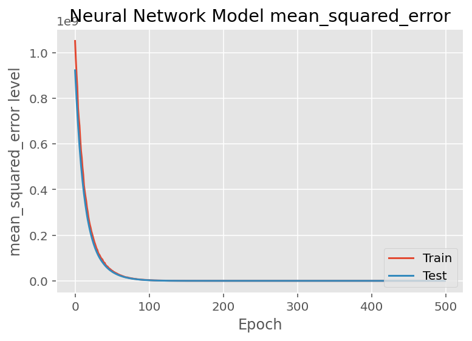

```python
# Model configuration
input_dim = 13
layer_units = [4, 4]
layer_activations = ['relu', 'relu']
layer_dropout_rates = [0.05, 0.01]
loss = 'mean_squared_error'
metrics = ['mean_squared_error']
learning_rate = 0.01
epochs = 500
batch_size = 64

# Setting up the model
model = Sequential()
model.add(Dense(layer_units[0], input_dim=input_dim, activation=layer_activations[0]))
model.add(Dropout(layer_dropout_rates[0]))
model.add(Dense(layer_units[1], activation=layer_activations[1]))
model.add(Dropout(layer_dropout_rates[1]))
model.add(Dense(1, activation='linear'))

model.compile(loss=loss, optimizer='Adam', metrics=metrics)

# Model training
history = model.fit(D_train, t_train, epochs=epochs,
                    batch_size=batch_size, verbose=0,
                    shuffle=True, validation_data=(D_train, t_train))

# Utility function for plotting Neural Network performance during training
def plot_history(history):
    plt.plot(history.history['mean_squared_error'])
    plt.plot(history.history['val_mean_squared_error'])
    plt.title('Neural Network Model mean_squared_error')
    plt.ylabel('mean_squared_error level')
    plt.xlabel('Epoch')
    plt.legend(['Train', 'Test'], loc='lower right')
    plt.show()

plot_history(history)
```

#### Neural Network 2

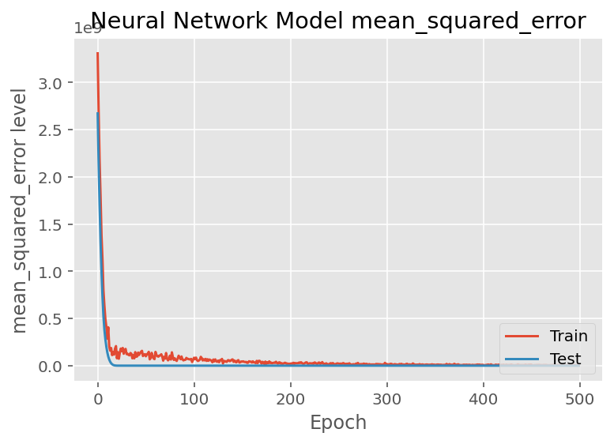

```python
# Define the model parameters
layer_units = [8, 8]
loss = 'mean_squared_error'
metrics = ['mean_squared_error']
epochs = 500
batch_size = 64
layer_activations = ['relu', 'relu']
layer_dropout_rates = [0.05, 0.01]

# Setting up the model
def create_model(input_dim, layer_units, layer_activations, layer_dropout_rates):
    model = Sequential()
    for units, activation, dropout_rate in zip(layer_units, layer_activations, layer_dropout_rates):
        model.add(Dense(units, input_dim=input_dim, activation=activation))
        model.add(Dropout(dropout_rate))
    model.add(Dense(1, activation='linear'))
    model.compile(loss=loss, optimizer='Adam', metrics=metrics)
    return model

# Model training
model = create_model(heart_data.shape[1], layer_units, layer_activations, layer_dropout_rates)
history = model.fit(D_train, t_train, epochs=epochs, batch_size=batch_size, verbose=0, shuffle=True, validation_data=(D_train, t_train))

# Utility function for plotting Neural Network performance during training
def plot_history(history):
    plt.plot(history.history['mean_squared_error'])
    plt.plot(history.history['val_mean_squared_error'])
    plt.title('Neural Network Model mean_squared_error')
    plt.ylabel('mean_squared_error level')
    plt.xlabel('Epoch')
    plt.legend(['Train', 'Test'], loc='lower right')
    plt.show()

plot_history(history)
```

#### Neural Network 3

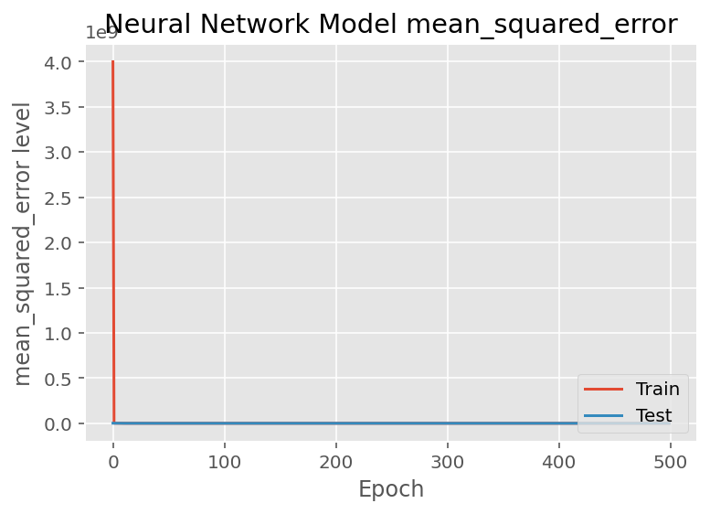

```python
from tensorflow.keras.models import Sequential
from tensorflow.keras.layers import Dense, Dropout
import matplotlib.pyplot as plt

layer1_units = 8
layer2_units = 6

loss = 'mean_squared_error'
metrics = ['mean_squared_error']

epochs = 500
batch_size = 64

layer1_activation = 'relu'
layer2_activation = 'relu'

layer1_dropout_rate = 0.05
layer2_dropout_rate = 0.2

# Setting up the model
def create_model(input_dim):
    model = Sequential([
        Dense(layer1_units, input_dim=input_dim, activation=layer1_activation),
        Dropout(layer1_dropout_rate),
        Dense(layer2_units, activation=layer2_activation),
        Dropout(layer2_dropout_rate),
        Dense(1, activation='linear')
    ])
    model.compile(loss=loss, optimizer='SGD', metrics=metrics)
    return model

# Model training
model = create_model(heart_data.shape[1])
history = model.fit(D_train, t_train, epochs=epochs,
                    batch_size=batch_size, verbose=0,
                    shuffle=True, validation_data=(D_train, t_train))

# Utility function for plotting Neural Network performance during training
def plot_history(history):
    plt.plot(history.history['mean_squared_error'])
    plt.plot(history.history['val_mean_squared_error'])
    plt.title('Neural Network Model mean_squared_error')
    plt.ylabel('mean_squared_error level')
    plt.xlabel('Epoch')
    plt.legend(['Train', 'Test'], loc='lower right')
    plt.show()

plot_history(history)
```

#### Neural Network 4

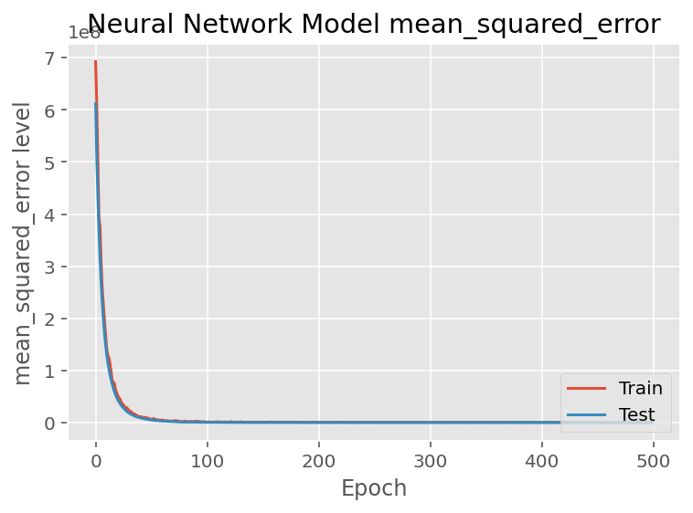

```python
from sklearn.model_selection import train_test_split

target1 = target.values.reshape(-1, 1)
D_train, D_test, t_train, t_test = train_test_split(heart_data, target1, test_size=0.3, random_state=44)

# size of the network is determined by the number of neural units in each hidden layer
layer1_units = 8
layer2_units = 6
layer3_units = 6
layer4_units = 4

loss = 'mean_squared_error'
# during training, we would like to monitor accuracy
metrics = ['mean_squared_error']

epochs = 500
batch_size = 64

layer1_activation = 'relu'
layer2_activation = 'relu'

layer1_dropout_rate = 0.05
layer2_dropout_rate = 0.01
layer3_dropout_rate = 0.02
layer4_dropout_rate = 0.01

# Setting up the model
def create_model(input_dim):
    model = Sequential([
        Dense(layer1_units, input_dim=input_dim, activation=layer1_activation),
        Dropout(layer1_dropout_rate),
        Dense(layer2_units, activation=layer2_activation),
        Dropout(layer2_dropout_rate),
        Dense(layer3_units, activation=layer2_activation),
        Dropout(layer3_dropout_rate),
        Dense(layer4_units, activation=layer2_activation),
        Dropout(layer4_dropout_rate),
        Dense(1, activation='linear')
    ])
    model.compile(loss=loss, optimizer='Adam', metrics=metrics)
    return model

# Model training
model = create_model(heart_data.shape[1])
history = model.fit(D_train, t_train, epochs=epochs,
                    batch_size=batch_size, verbose=0,
                    shuffle=True, validation_data=(D_train, t_train))

# Utility function for plotting Neural Network performance during training
def plot_history(history):
    plt.plot(history.history['mean_squared_error'])
    plt.plot(history.history['val_mean_squared_error'])
    plt.title('Neural Network Model mean_squared_error')
    plt.ylabel('mean_squared_error level')
    plt.xlabel('Epoch')
    plt.legend(['Train', 'Test'], loc='lower right')
    plt.show()

plot_history(history)
```

#### Neural Network 5

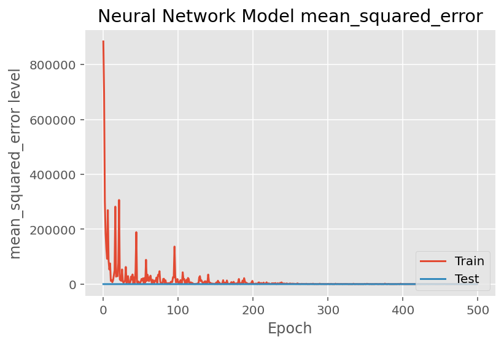

```python
from sklearn.model_selection import train_test_split

target1 = target.values.reshape(-1, 1)
D_train, D_test, t_train, t_test = train_test_split(heart_data, target1, test_size=0.3, random_state=44)

# size of the network is determined by the number of neural units in each hidden layer
layer1_units = 8
layer2_units = 6
layer3_units = 6
layer4_units = 4

loss = 'mean_squared_error'
# during training, we would like to monitor accuracy
metrics = ['mean_squared_error']

epochs = 500
batch_size = 64

layer1_activation = 'relu'
layer2_activation = 'relu'

layer1_dropout_rate = 0.05
layer2_dropout_rate = 0.01
layer3_dropout_rate = 0.02
layer4_dropout_rate = 0.01

# Setting up the model
def create_model(input_dim):
    model = Sequential([
        Dense(layer1_units, input_dim=input_dim, activation=layer1_activation),
        Dropout(layer1_dropout_rate),
        Dense(layer2_units, activation=layer2_activation),
        Dropout(layer2_dropout_rate),
        Dense(layer3_units, activation=layer2_activation),
        Dropout(layer3_dropout_rate),
        Dense(layer4_units, activation=layer2_activation),
        Dropout(layer4_dropout_rate),
        Dense(1, activation='linear')
    ])
    model.compile(loss=loss, optimizer='Adam', metrics=metrics)
    return model

# Model training
model = create_model(heart_data.shape[1])
history = model.fit(D_train, t_train, epochs=epochs,
                    batch_size=batch_size, verbose=0,
                    shuffle=True, validation_data=(D_train, t_train))

# Utility function for plotting Neural Network performance during training
def plot_history(history):
    plt.plot(history.history['mean_squared_error'])
    plt.plot(history.history['val_mean_squared_error'])
    plt.title('Neural Network Model mean_squared_error')
    plt.ylabel('mean_squared_error level')
    plt.xlabel('Epoch')
    plt.legend(['Train', 'Test'], loc='lower right')
    plt.show()

plot_history(history)
```

### 2.3. Model Camparision :

During the hyper-parameter tuning phase above, we used the 223 rows in our training data within a cross-validation framework and we determined the best hyper-parameter values for each classifier models.

We would like to perform pairwise t-tests to determine if there is any significant difference between the performance of any two (tuned) classifier models using cross validation. We first perform 10-fold stratified cross-validation (without any repetitions) on each (tuned) classifier model where we use the same seed in each of the four cross-validation runs. Second, we conduct a paired t-test for the AUC score.

#### K-Nearest Neighbour (KNN) :

```python
from sklearn.model_selection import cross_val_score

cv_method_ttest = StratifiedKFold(n_splits=10, shuffle=True, random_state=111)

gs_pipe_KNN.fit(Data_sample_test, target_sample_test)

# Access the best estimator and perform cross-validation
best_estimator_KNN = gs_pipe_KNN.best_estimator_
cv_results_KNN = cross_val_score(estimator=best_estimator_KNN,
                                 X=Data_sample_test,
                                 y=target_sample_test,
                                 cv=cv_method_ttest,
                                 n_jobs=-2,
                                 scoring='roc_auc')

print("Mean of KNN's AUC scores using 10 fold cross validation:", cv_results_KNN.mean())
```

```
Fitting 5 folds for each of 30 candidates, totalling 150 fits
Mean of KNN's AUC scores using 10 fold cross validation: 0.66875
```

#### Naive Bayes (NB) :

```python
Data_sample_test_transformed = PowerTransformer().fit_transform(Data_sample_test)

cv_results_NB = cross_val_score(estimator=gs_pipe_NB.best_estimator_,
                                X=Data_sample_test_transformed,
                                y=target_sample_test,
                                cv=cv_method_ttest,
                                n_jobs=-2,
                                scoring='roc_auc')

print("Mean of Naive Bayes's AUC scores using 10 fold cross validation:", cv_results_NB.mean())
```

```
Mean of Naive Bayes's AUC scores using 10 fold cross validation: 0.8125
```

#### Decision Tree(DT):

```python
cv_results_DT = cross_val_score(estimator=gs_pipe_DT2.best_estimator_,
                                X=Data_sample_test,
                                y=target_sample_test,
                                cv=cv_method_ttest,
                                n_jobs=-2,
                                scoring='roc_auc')

print("Mean of Decision Tree's AUC scores using 10 fold cross validation:", cv_results_DT.mean())
```

```
Mean of Decision Tree's AUC scores using 10 fold cross validation: 0.5
```

#### XGBoost (XGB):

```python
cv_results_XG = cross_val_score(estimator=gs_pipe_XG2.best_estimator_,
                                X=Data_sample_test,
                                y=target_sample_test,
                                cv=cv_method_ttest,
                                n_jobs=-2,
                                scoring='roc_auc')

print("Mean of Decision Tree's AUC scores using 10 fold cross validation:", cv_results_XG.mean())
```

```
Mean of Decision Tree's AUC scores using 10 fold cross validation: 0.6666666666666666
```

Results are statistically "paired" since all (tuned) classifiers were fitted and subsequently tested on precisely the same data partitions. This is because we fixed the random state to be the same during cross-validation. The paired t-tests below are thus done using the stats.ttest_rel function from the SciPy library.

Thus, we conduct a paired t-test for the AUC score between the following (tuned) classifier combinations:

NB vs. KNN, NB vs. XG, and KNN vs. XG

```python
from scipy import stats

print(stats.ttest_rel(cv_results_NB, cv_results_KNN))
print(stats.ttest_rel(cv_results_NB, cv_results_XG))
print(stats.ttest_rel(cv_results_KNN, cv_results_XG))
```

```
Ttest_relResult(statistic=1.1498403110455397, pvalue=0.2798460668987391)
Ttest_relResult(statistic=1.8843366572035793, pvalue=0.09216607557770636)
Ttest_relResult(statistic=0.01619163400101507, pvalue=0.9874347715890354)
```

A p-value smaller than 0.05 indicates a statistically significant difference. Looking at these results, we observe that the difference between NB/ KNN, NB/ XG, and KNN/XG pairs are not statistically significant (p-values are greater than 0.05). Even though the NB model has the higher AUC mean value compared to other models, from the above test we conclude that there is no significant diffrence between these 3 models.

## 3. Critique & Limitations

Additionally, the models are developed based on the assumption that the selected features are the most informative for predicting heart failure. However, there may be other relevant factors that are not included in the dataset, such as genetic or lifestyle factors, which could impact the accuracy of the predictions.

Moreover, models using retrospective data may not account for changes in medical practices or temporal changes. This could limit the effectiveness of the models in real-time applications or for future outcome predictions.

Lastly, ethical and privacy concerns should also be taken into consideration when using clinical records for prediction. It's crucial to ensure that patients are treated fairly and without bias, sensitive information is protected, and any potential biases in the data and models are addressed.

Overall, while models based on clinical records can provide valuable insights, it's important to interpret their results with caution and consider their limitations in terms of data quality, feature representation, temporal dynamics, and ethical considerations.

## 4. Summary & Conclusions

### 4.1. Project Summary :

To evaluate the models, they were trained on a portion of the dataset and evaluated on both the training and validation sets. A utility function was used to plot the mean squared error for both sets during the training process.

It is important to note the limitations of the models and the analysis performed. These include the small size of the dataset, potential biases in the data, the assumption that the selected features were the most informative, and the lack of consideration for external factors like genetics or lifestyle. Ethical and privacy concerns were also noted.

In summary, this project involved the development of neural network models for heart failure prediction using clinical records. The models were trained and evaluated on the dataset, and their performance was monitored using mean squared error. The project summary also highlighted the limitations and caveats to consider when interpreting the results and using clinical records for prediction.

### 4.3. Conclusions :

We conducted pairwise t-tests and found no statistically significant differences between the AUC scores of the Naive Bayes, K-Nearest Neighbors, and XGBoost models, indicating comparable performance among these models.

## 5. References

UCI Machine Learning Repository: Heart failure clinical records Data Set. (n.d.). https://archive.ics.uci.edu/ml/datasets/Heart+failure+clinical+records

Alashhab, A. J. (2022, February 2). Using Machine learning Algorithm in Heart Failure Clinical Records Dataset. Medium. https://medium.com/@ammar.j.alashhab/using-machine-learning-algorithm-in-heart-failure-clinical-records-dataset-4e862b69e55c

Keras documentation: Working with RNNs. (n.d.). Keras: Deep Learning for humans. https://keras.io/guides/working_with_rnns/

Pairwise T-Test : Excellent Reference You Will Love - Datanovia. (n.d.). Datanovia. https://www.datanovia.com/en/lessons/pairwise-t-test/

valbauman. (2020, August 24). Feature selection for heart disease prediction. Kaggle: Your Machine Learning and Data Science Community. https://www.kaggle.com/code/valbauman/feature-selection-for-heart-disease-prediction#Feature-Selection---L1-Regularization

sachinsharma1123. (2020, December 26). intro. to feature engineering and selection. Kaggle: Your Machine Learning and Data Science Community. https://www.kaggle.com/code/sachinsharma1123/intro-to-feature-engineering-and-selection#Feature-Engineering

paotografi. (2021, January 28). Heart Failure Prediction - KNN/RandForest/NBayes. Kaggle: Your Machine Learning and Data Science Community. https://www.kaggle.com/code/paotografi/heart-failure-prediction-knn-randforest-nbayes

benyamingheiji. (2023, May 5). EDA + Data analysis + 7 Machine learning models. Kaggle: Your Machine Learning and Data Science Community. https://www.kaggle.com/code/benyamingheiji/eda-data-analysis-7-machine-learning-models

End of Report